# Class 3 notes

#### Geoms

Once the base setup is done, you can append the geoms one on top of the other by using the plus sign! So technically all plots can be produced with the same structre:

basesetup + geom 1 + geom 2 + …

There is a lot of different geoms in the ggplot2 package. See the cheatsheet to have an idea: https://www.rstudio.com/wp-content/uploads/2015/03/ggplot2-cheatsheet.pdf

##### geom_histogram()

geom_histogram() shows distribution of values, i.e. how many times which value has appeared in data

Let’s say we just want to see what is going on in the tongue_twist measure. We know that this measure is continuous. From the cheatsheet, we can see that one of our options for a continuous variable is using geom_histogram:

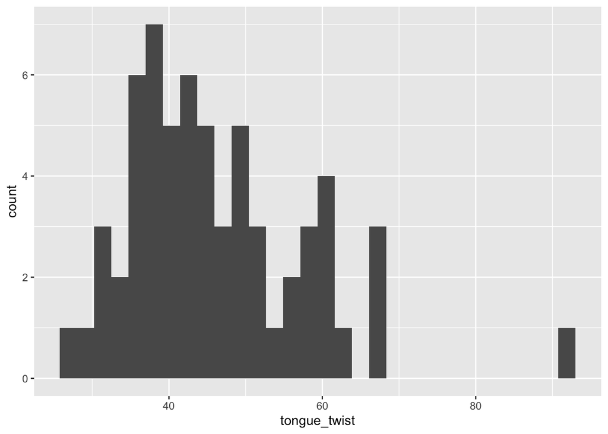

```r
ggplot(Pers_Data, aes(x=tongue_twist))+
  geom_histogram()
```

We can kind of see already, what is going on, but let’s make it prettier by changing one of parameters of the geom:

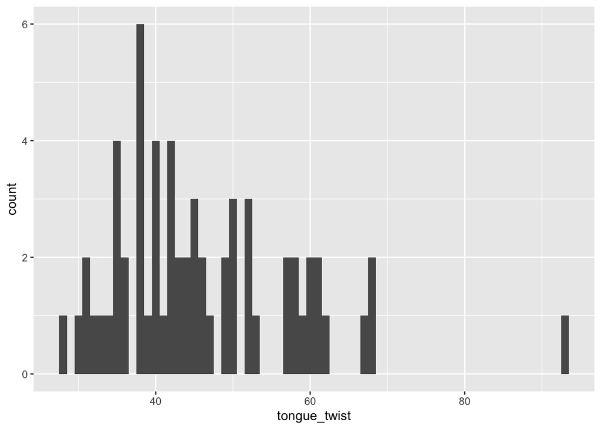

```r
ggplot(Pers_Data, aes(x=tongue_twist))+
  geom_histogram(binwidth = 1) #you can change binwidth if you want to, it's cosmetic
```

Geom_histrogram just showed counts for different values of tongue twister column - majority reported time around 40 seconds.

Bonus question: Is there something weird with tongue twister data?

Practice: Make a ggplot with geom_histogram to see distribution of choose_rand_num (Make a code chunk for it).

Question: Do you think it’s normally distributed?

Next week we will learn how to check for sure!

##### geom_bar()

Bar plots are fun and pretty simple. Bar plots work especially well, when x coordinate is categorical If we specify only x coordinate - geom_bar will put counts on y coordinate.

Let’s try it out by setting x coordinate to show gender and plotting geom_bar:

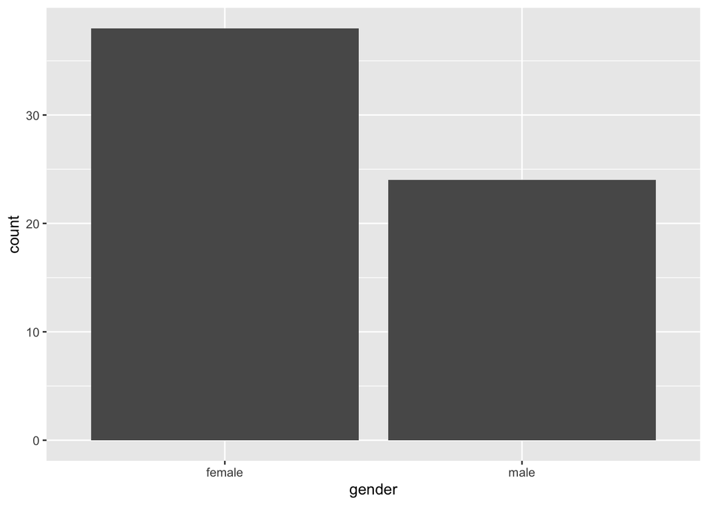

```r
ggplot(Pers_Data, aes(x=gender))+
  geom_bar()
```

If we know y-coordinate too, then we need to help geom_bar() to decide what to do with data instead of counting:

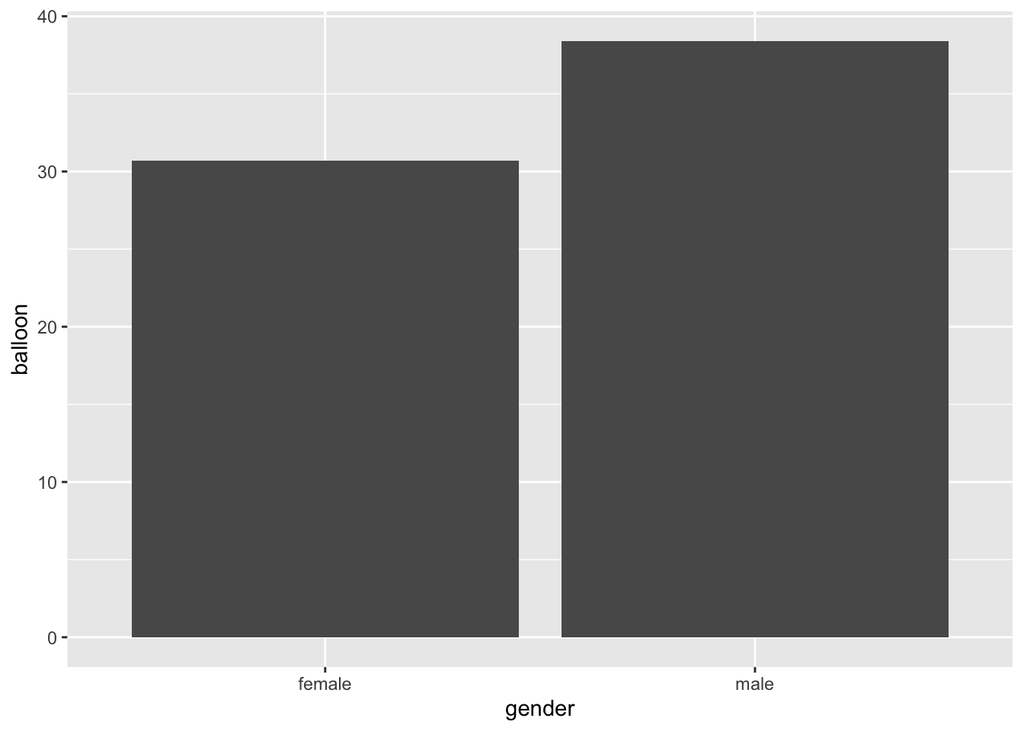

```r
ggplot(Pers_Data, aes(x=gender, y=balloon))+
  geom_bar(stat='summary', fun.y = mean) #we ask to show us the mean of values on y coordinate
```

As you can see, geoms are pretty flexible! We can change functionality by changing stuff in parantheses - as you saw in geom_bar(stat=‘summary’, fun.y = mean)

##### geom_errorbar()

Needs specification in the parantheses to claculate and plot standard error of the mean : geom_errorbar(stat = ‘summary’, fun.data = mean_se)

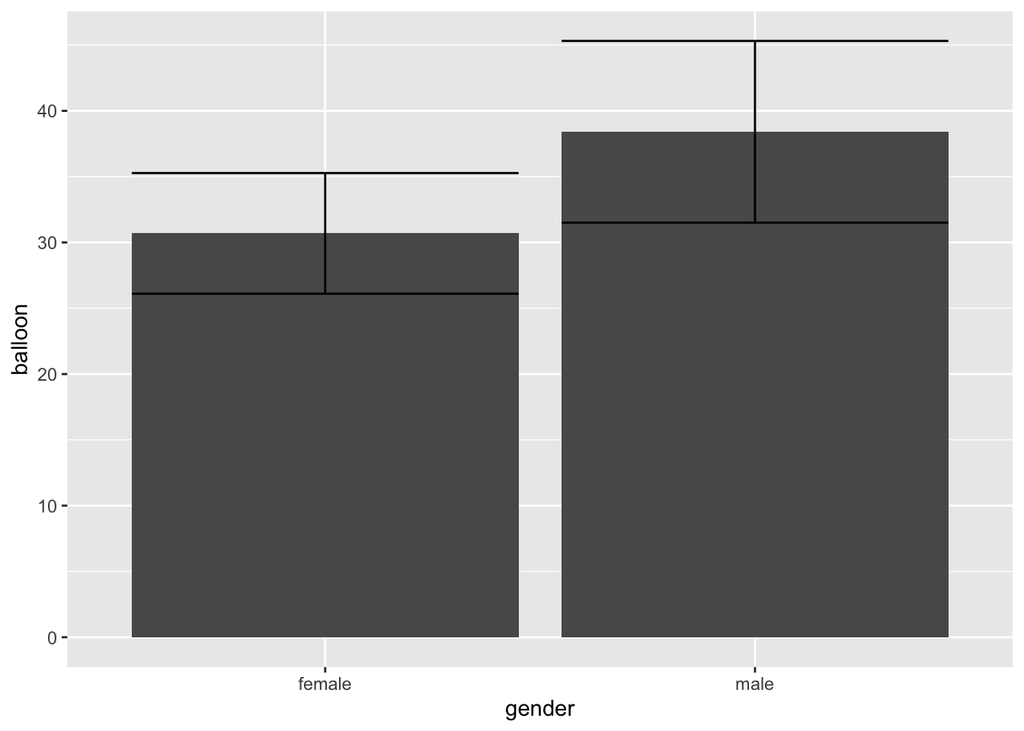

```r
ggplot(Pers_Data, aes(x=gender, y=balloon))+
  geom_bar(stat='summary', fun.y = mean)+
  geom_errorbar(stat = 'summary', fun.data = mean_se)
```

##### More layers and aesthetics

With ggplot, we can get more and more layers and settings - to make the plot look exactly like we want it.

I tried to make the previous plot pretty.

Try to understand the script below, what does each geom do? What happens when you change settings?

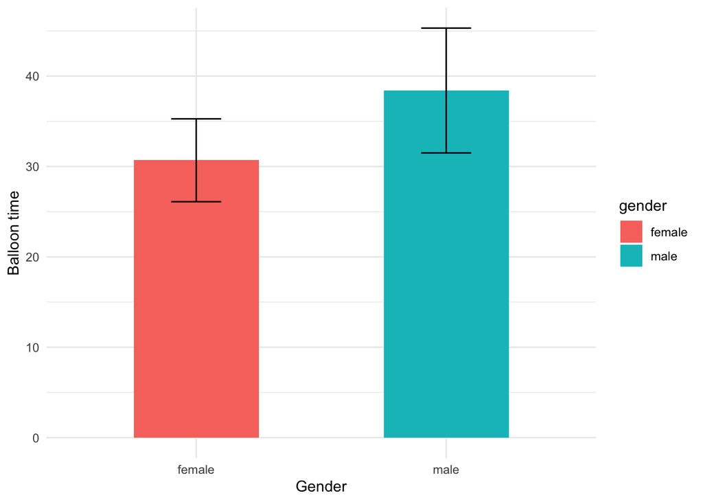

```r
ggplot(Pers_Data, aes(x=gender, y=balloon, fill = gender))+
  geom_bar(stat='summary', fun.y = mean, width = 0.5)+
  geom_errorbar(stat = 'summary', fun.data = mean_se, width = 0.2)+
  labs(x = "Gender", y = "Balloon time")+
  theme_minimal()
```

#### Visualization exercise

1. Identically to bar plots we’ve made above, make a bar plot showing average shoesize according to handedness.
2. Try to make it pretty!

## Homework exercises

1. Make sure to finish Part 2 - before Tuesday Cognition and Communication class (just read it and solve the 3 questions in exercises, you’ll feel better in the class)
2. Do the visualization exercise
3. Play around with Ggplot! Use the ggplot cheatsheet, change different parts of your code and see what changed

3.(Optional) Go through Chapter 3 in ‘R for Data Science’ book (http://r4ds.had.co.nz/index.html)